# My R Markdown

Destini Randall

2026-04-12

## Introduction

R Markdown is a file format for writing reproducible documents with R. It is used to embed R code and text into HTML, PDF, Word, and more.

## Narrative Paragraph

Using R Markdown makes reading code, text, and results much easier. In this assignment I am going to practice integrating paragraphs, LaTeX math, and executable R code chunks into an R markdown file. Then I will knit the document, push it to my GitHub repository, and reflect on my process.

## LaTeX Math Expression

Inline: $A = 5x + x^2$

Displayed:
$$B = 7 + x/2$$

## R Code Chunks

```r
data("iris")
mean(iris$Petal.Length)
```

```
## [1] 3.758
```

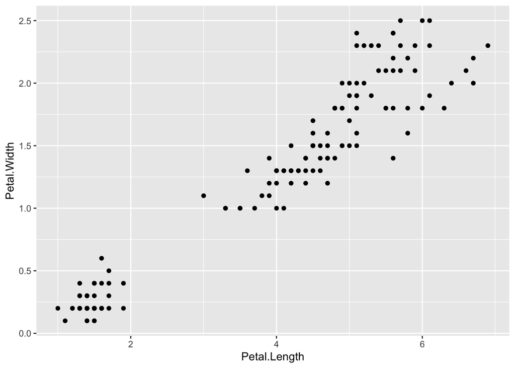

```r
library(ggplot2)
ggplot(iris, aes(x = Petal.Length, y = Petal.Width)) + geom_point()
```

## Reflection

Using R Markdown compared to writing a plain report was very nice when working with code. Just like word that has formatting rules, there are syntax rules in markdown that I needed to learn. After learning those however, R markdown is clearly more efficient because it lets me code normally and write all at once. If I wanted to provide code in a normal word document it is very hard to format correctly. I also like being able to run the individual code chunks and see their output directly underneath.